# Risk Factor Analysis

## Outcome Variable

**Outcome Variable:** stunted

## Predictor Variables

**Intervention Variable:** cleanck

**Adjustment Set:**

- arm
- sex
- W_mage
- meducyrs
- feducyrs
- hhwealth_quart
- W_nrooms
- W_nhh
- W_nchldlt5
- trth2o
- impfloor
- delta_meducyrs
- delta_feducyrs
- delta_hhwealth_quart
- delta_W_nrooms
- delta_W_nhh
- delta_W_nchldlt5
- delta_trth2o
- delta_impfloor

## Stratifying Variables

The analysis was stratified on these variable(s):

- agecat
- studyid
- country

## Data Summary

| agecat | studyid | country | cleanck | stunted | n_cell | n |
| --- | --- | --- | --- | --- | --- | --- |
| Birth | ki0047075b-MAL-ED | PERU | 1 | 0 | 1 | 2 |
| Birth | ki0047075b-MAL-ED | PERU | 1 | 1 | 0 | 2 |
| Birth | ki0047075b-MAL-ED | PERU | 0 | 0 | 1 | 2 |
| Birth | ki0047075b-MAL-ED | PERU | 0 | 1 | 0 | 2 |
| Birth | ki1000108-CMC-V-BCS-2002 | INDIA | 1 | 0 | 35 | 92 |
| Birth | ki1000108-CMC-V-BCS-2002 | INDIA | 1 | 1 | 4 | 92 |
| Birth | ki1000108-CMC-V-BCS-2002 | INDIA | 0 | 0 | 40 | 92 |
| Birth | ki1000108-CMC-V-BCS-2002 | INDIA | 0 | 1 | 13 | 92 |
| Birth | ki1000108-IRC | INDIA | 1 | 0 | 197 | 378 |
| Birth | ki1000108-IRC | INDIA | 1 | 1 | 21 | 378 |
| Birth | ki1000108-IRC | INDIA | 0 | 0 | 138 | 378 |
| Birth | ki1000108-IRC | INDIA | 0 | 1 | 22 | 378 |
| Birth | ki1017093b-PROVIDE | BANGLADESH | 1 | 0 | 400 | 539 |
| Birth | ki1017093b-PROVIDE | BANGLADESH | 1 | 1 | 38 | 539 |
| Birth | ki1017093b-PROVIDE | BANGLADESH | 0 | 0 | 91 | 539 |
| Birth | ki1017093b-PROVIDE | BANGLADESH | 0 | 1 | 10 | 539 |
| Birth | ki1017093c-NIH-Crypto | BANGLADESH | 1 | 0 | 301 | 561 |
| Birth | ki1017093c-NIH-Crypto | BANGLADESH | 1 | 1 | 44 | 561 |
| Birth | ki1017093c-NIH-Crypto | BANGLADESH | 0 | 0 | 183 | 561 |
| Birth | ki1017093c-NIH-Crypto | BANGLADESH | 0 | 1 | 33 | 561 |
| Birth | ki1113344-GMS-Nepal | NEPAL | 1 | 0 | 9 | 621 |
| Birth | ki1113344-GMS-Nepal | NEPAL | 1 | 1 | 0 | 621 |
| Birth | ki1113344-GMS-Nepal | NEPAL | 0 | 0 | 506 | 621 |
| Birth | ki1113344-GMS-Nepal | NEPAL | 0 | 1 | 106 | 621 |
| 6 months | ki0047075b-MAL-ED | SOUTH AFRICA | 1 | 0 | 1 | 1 |
| 6 months | ki0047075b-MAL-ED | SOUTH AFRICA | 1 | 1 | 0 | 1 |
| 6 months | ki0047075b-MAL-ED | SOUTH AFRICA | 0 | 0 | 0 | 1 |
| 6 months | ki0047075b-MAL-ED | SOUTH AFRICA | 0 | 1 | 0 | 1 |
| 6 months | ki1000108-CMC-V-BCS-2002 | INDIA | 1 | 0 | 123 | 369 |
| 6 months | ki1000108-CMC-V-BCS-2002 | INDIA | 1 | 1 | 40 | 369 |
| 6 months | ki1000108-CMC-V-BCS-2002 | INDIA | 0 | 0 | 135 | 369 |
| 6 months | ki1000108-CMC-V-BCS-2002 | INDIA | 0 | 1 | 71 | 369 |
| 6 months | ki1000108-IRC | INDIA | 1 | 0 | 181 | 398 |
| 6 months | ki1000108-IRC | INDIA | 1 | 1 | 49 | 398 |
| 6 months | ki1000108-IRC | INDIA | 0 | 0 | 119 | 398 |
| 6 months | ki1000108-IRC | INDIA | 0 | 1 | 49 | 398 |
| 6 months | ki1017093b-PROVIDE | BANGLADESH | 1 | 0 | 429 | 604 |
| 6 months | ki1017093b-PROVIDE | BANGLADESH | 1 | 1 | 69 | 604 |
| 6 months | ki1017093b-PROVIDE | BANGLADESH | 0 | 0 | 79 | 604 |
| 6 months | ki1017093b-PROVIDE | BANGLADESH | 0 | 1 | 27 | 604 |
| 6 months | ki1017093c-NIH-Crypto | BANGLADESH | 1 | 0 | 264 | 545 |
| 6 months | ki1017093c-NIH-Crypto | BANGLADESH | 1 | 1 | 65 | 545 |
| 6 months | ki1017093c-NIH-Crypto | BANGLADESH | 0 | 0 | 179 | 545 |
| 6 months | ki1017093c-NIH-Crypto | BANGLADESH | 0 | 1 | 37 | 545 |
| 6 months | ki1113344-GMS-Nepal | NEPAL | 1 | 0 | 8 | 505 |
| 6 months | ki1113344-GMS-Nepal | NEPAL | 1 | 1 | 0 | 505 |
| 6 months | ki1113344-GMS-Nepal | NEPAL | 0 | 0 | 388 | 505 |
| 6 months | ki1113344-GMS-Nepal | NEPAL | 0 | 1 | 109 | 505 |
| 24 months | ki0047075b-MAL-ED | SOUTH AFRICA | 1 | 0 | 1 | 1 |
| 24 months | ki0047075b-MAL-ED | SOUTH AFRICA | 1 | 1 | 0 | 1 |
| 24 months | ki0047075b-MAL-ED | SOUTH AFRICA | 0 | 0 | 0 | 1 |
| 24 months | ki0047075b-MAL-ED | SOUTH AFRICA | 0 | 1 | 0 | 1 |
| 24 months | ki1000108-CMC-V-BCS-2002 | INDIA | 1 | 0 | 67 | 371 |
| 24 months | ki1000108-CMC-V-BCS-2002 | INDIA | 1 | 1 | 96 | 371 |
| 24 months | ki1000108-CMC-V-BCS-2002 | INDIA | 0 | 0 | 38 | 371 |
| 24 months | ki1000108-CMC-V-BCS-2002 | INDIA | 0 | 1 | 170 | 371 |
| 24 months | ki1000108-IRC | INDIA | 1 | 0 | 142 | 400 |
| 24 months | ki1000108-IRC | INDIA | 1 | 1 | 89 | 400 |
| 24 months | ki1000108-IRC | INDIA | 0 | 0 | 89 | 400 |
| 24 months | ki1000108-IRC | INDIA | 0 | 1 | 80 | 400 |
| 24 months | ki1017093b-PROVIDE | BANGLADESH | 1 | 0 | 338 | 578 |
| 24 months | ki1017093b-PROVIDE | BANGLADESH | 1 | 1 | 141 | 578 |
| 24 months | ki1017093b-PROVIDE | BANGLADESH | 0 | 0 | 50 | 578 |
| 24 months | ki1017093b-PROVIDE | BANGLADESH | 0 | 1 | 49 | 578 |
| 24 months | ki1017093c-NIH-Crypto | BANGLADESH | 1 | 0 | 156 | 410 |
| 24 months | ki1017093c-NIH-Crypto | BANGLADESH | 1 | 1 | 43 | 410 |
| 24 months | ki1017093c-NIH-Crypto | BANGLADESH | 0 | 0 | 167 | 410 |
| 24 months | ki1017093c-NIH-Crypto | BANGLADESH | 0 | 1 | 44 | 410 |
| 24 months | ki1113344-GMS-Nepal | NEPAL | 1 | 0 | 5 | 435 |
| 24 months | ki1113344-GMS-Nepal | NEPAL | 1 | 1 | 0 | 435 |
| 24 months | ki1113344-GMS-Nepal | NEPAL | 0 | 0 | 232 | 435 |
| 24 months | ki1113344-GMS-Nepal | NEPAL | 0 | 1 | 198 | 435 |

The following strata were considered:

- agecat: 24 months, studyid: ki0047075b-MAL-ED, country: SOUTH AFRICA
- agecat: 24 months, studyid: ki1000108-CMC-V-BCS-2002, country: INDIA
- agecat: 24 months, studyid: ki1000108-IRC, country: INDIA
- agecat: 24 months, studyid: ki1017093b-PROVIDE, country: BANGLADESH
- agecat: 24 months, studyid: ki1017093c-NIH-Crypto, country: BANGLADESH
- agecat: 24 months, studyid: ki1113344-GMS-Nepal, country: NEPAL
- agecat: 6 months, studyid: ki0047075b-MAL-ED, country: SOUTH AFRICA
- agecat: 6 months, studyid: ki1000108-CMC-V-BCS-2002, country: INDIA
- agecat: 6 months, studyid: ki1000108-IRC, country: INDIA
- agecat: 6 months, studyid: ki1017093b-PROVIDE, country: BANGLADESH
- agecat: 6 months, studyid: ki1017093c-NIH-Crypto, country: BANGLADESH
- agecat: 6 months, studyid: ki1113344-GMS-Nepal, country: NEPAL
- agecat: Birth, studyid: ki0047075b-MAL-ED, country: PERU
- agecat: Birth, studyid: ki1000108-CMC-V-BCS-2002, country: INDIA
- agecat: Birth, studyid: ki1000108-IRC, country: INDIA
- agecat: Birth, studyid: ki1017093b-PROVIDE, country: BANGLADESH
- agecat: Birth, studyid: ki1017093c-NIH-Crypto, country: BANGLADESH
- agecat: Birth, studyid: ki1113344-GMS-Nepal, country: NEPAL

### Dropped Strata

Some strata were dropped due to rare outcomes:

- agecat: Birth, studyid: ki0047075b-MAL-ED, country: PERU
- agecat: Birth, studyid: ki1000108-CMC-V-BCS-2002, country: INDIA
- agecat: Birth, studyid: ki1113344-GMS-Nepal, country: NEPAL
- agecat: 6 months, studyid: ki0047075b-MAL-ED, country: SOUTH AFRICA
- agecat: 6 months, studyid: ki1113344-GMS-Nepal, country: NEPAL
- agecat: 24 months, studyid: ki0047075b-MAL-ED, country: SOUTH AFRICA
- agecat: 24 months, studyid: ki1113344-GMS-Nepal, country: NEPAL

## Methods Detail

We’re interested in the causal parameters $E[Y_a]$ for all values of $a \in \mathcal{A}$. These parameters represent the mean outcome if, possibly contrary to fact, we intervened to set all units to have $A=a$. Under the randomization and positivity assumptions, these are identified by the statistical parameters $\psi_a=E_W[E_{Y|A,W}(Y|A=a,W)]$. In addition, we’re interested in the mean of $Y$, $E[Y]$ under no intervention (the observed mean). We will estimate these parameters by using SuperLearner to fit the relevant likelihood factors – $E_{Y|A,W}(Y|A=a,W)$ and $p(A=a|W)$, and then updating our likelihood fit using a joint TMLE.

For unadjusted analyses ($W=\{\}$), initial likelihoods were estimated using Lrnr_glm to estimate the simple $E(Y|A)$ and Lrnr_mean to estimate $p(A)$. For adjusted analyses, a small library containing Lrnr_glmnet, Lrnr_xgboost, and Lrnr_mean was used.

Having estimated these parameters, we will then use the delta method to estimate relative risks and attributable risks relative to a prespecified baseline level of $A$.

# Results Detail

## Results Plots

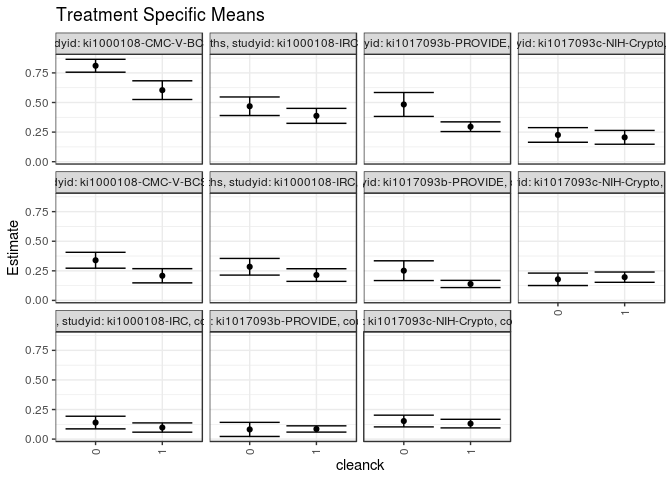

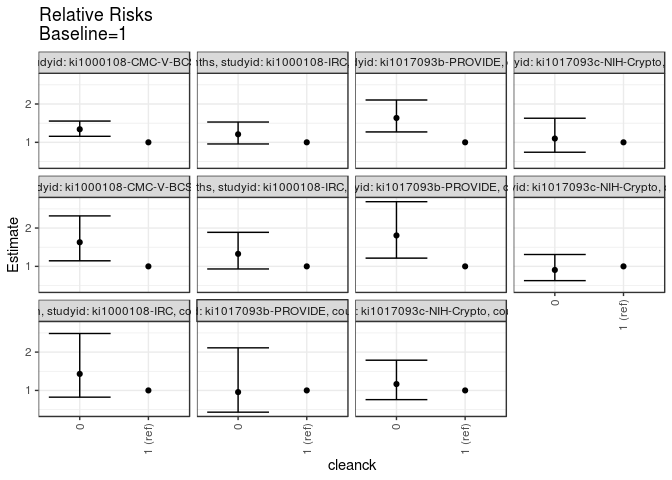

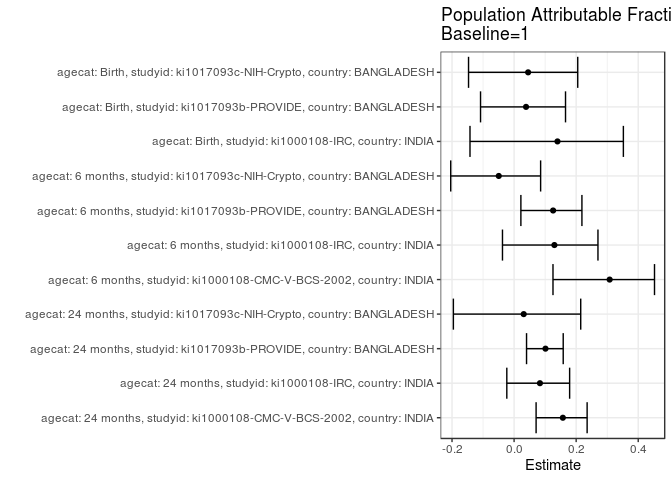

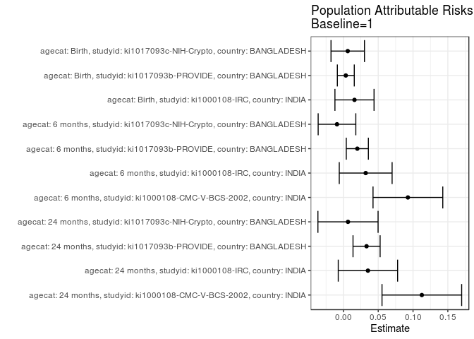

## Results Table

### Parameter: TSM

| agecat | studyid | country | intervention_level | baseline_level | estimate | ci_lower | ci_upper |
| --- | --- | --- | --- | --- | --- | --- | --- |
| Birth | ki1000108-IRC | INDIA | 1 | NA | 0.0978528 | 0.0587216 | 0.1369839 |
| Birth | ki1000108-IRC | INDIA | 0 | NA | 0.1400201 | 0.0867143 | 0.1933258 |
| Birth | ki1017093b-PROVIDE | BANGLADESH | 1 | NA | 0.0856238 | 0.0591789 | 0.1120688 |
| Birth | ki1017093b-PROVIDE | BANGLADESH | 0 | NA | 0.0818851 | 0.0223294 | 0.1414407 |
| Birth | ki1017093c-NIH-Crypto | BANGLADESH | 1 | NA | 0.1310479 | 0.0946185 | 0.1674772 |
| Birth | ki1017093c-NIH-Crypto | BANGLADESH | 0 | NA | 0.1527994 | 0.1032062 | 0.2023927 |
| 6 months | ki1000108-CMC-V-BCS-2002 | INDIA | 1 | NA | 0.2081754 | 0.1482147 | 0.2681360 |
| 6 months | ki1000108-CMC-V-BCS-2002 | INDIA | 0 | NA | 0.3391969 | 0.2720758 | 0.4063179 |
| 6 months | ki1000108-IRC | INDIA | 1 | NA | 0.2142456 | 0.1609266 | 0.2675646 |
| 6 months | ki1000108-IRC | INDIA | 0 | NA | 0.2842383 | 0.2138656 | 0.3546110 |
| 6 months | ki1017093b-PROVIDE | BANGLADESH | 1 | NA | 0.1389547 | 0.1084857 | 0.1694236 |
| 6 months | ki1017093b-PROVIDE | BANGLADESH | 0 | NA | 0.2510991 | 0.1676011 | 0.3345971 |
| 6 months | ki1017093c-NIH-Crypto | BANGLADESH | 1 | NA | 0.1964006 | 0.1529257 | 0.2398755 |
| 6 months | ki1017093c-NIH-Crypto | BANGLADESH | 0 | NA | 0.1780937 | 0.1256571 | 0.2305304 |
| 24 months | ki1000108-CMC-V-BCS-2002 | INDIA | 1 | NA | 0.6043242 | 0.5252104 | 0.6834379 |
| 24 months | ki1000108-CMC-V-BCS-2002 | INDIA | 0 | NA | 0.8105408 | 0.7559692 | 0.8651124 |
| 24 months | ki1000108-IRC | INDIA | 1 | NA | 0.3872943 | 0.3240672 | 0.4505214 |
| 24 months | ki1000108-IRC | INDIA | 0 | NA | 0.4684588 | 0.3899739 | 0.5469437 |
| 24 months | ki1017093b-PROVIDE | BANGLADESH | 1 | NA | 0.2954682 | 0.2545329 | 0.3364035 |
| 24 months | ki1017093b-PROVIDE | BANGLADESH | 0 | NA | 0.4832735 | 0.3821309 | 0.5844161 |
| 24 months | ki1017093c-NIH-Crypto | BANGLADESH | 1 | NA | 0.2056149 | 0.1473991 | 0.2638307 |
| 24 months | ki1017093c-NIH-Crypto | BANGLADESH | 0 | NA | 0.2259200 | 0.1640910 | 0.2877491 |

### Parameter: E(Y)

| agecat | studyid | country | intervention_level | baseline_level | estimate | ci_lower | ci_upper |
| --- | --- | --- | --- | --- | --- | --- | --- |
| Birth | ki1000108-IRC | INDIA | NA | NA | 0.1137566 | 0.0817056 | 0.1458077 |
| Birth | ki1017093b-PROVIDE | BANGLADESH | NA | NA | 0.0890538 | 0.0649864 | 0.1131212 |
| Birth | ki1017093c-NIH-Crypto | BANGLADESH | NA | NA | 0.1372549 | 0.1087540 | 0.1657558 |
| 6 months | ki1000108-CMC-V-BCS-2002 | INDIA | NA | NA | 0.3008130 | 0.2539566 | 0.3476694 |
| 6 months | ki1000108-IRC | INDIA | NA | NA | 0.2462312 | 0.2038529 | 0.2886094 |
| 6 months | ki1017093b-PROVIDE | BANGLADESH | NA | NA | 0.1589404 | 0.1297581 | 0.1881227 |
| 6 months | ki1017093c-NIH-Crypto | BANGLADESH | NA | NA | 0.1871560 | 0.1543801 | 0.2199318 |
| 24 months | ki1000108-CMC-V-BCS-2002 | INDIA | NA | NA | 0.7169811 | 0.6710815 | 0.7628807 |
| 24 months | ki1000108-IRC | INDIA | NA | NA | 0.4225000 | 0.3740325 | 0.4709675 |
| 24 months | ki1017093b-PROVIDE | BANGLADESH | NA | NA | 0.3287197 | 0.2903909 | 0.3670485 |
| 24 months | ki1017093c-NIH-Crypto | BANGLADESH | NA | NA | 0.2121951 | 0.1725707 | 0.2518196 |

### Parameter: RR

| agecat | studyid | country | intervention_level | baseline_level | estimate | ci_lower | ci_upper |
| --- | --- | --- | --- | --- | --- | --- | --- |
| Birth | ki1000108-IRC | INDIA | 1 | 1 | 1.0000000 | 1.0000000 | 1.000000 |
| Birth | ki1000108-IRC | INDIA | 0 | 1 | 1.4309260 | 0.8237951 | 2.485508 |
| Birth | ki1017093b-PROVIDE | BANGLADESH | 1 | 1 | 1.0000000 | 1.0000000 | 1.000000 |
| Birth | ki1017093b-PROVIDE | BANGLADESH | 0 | 1 | 0.9563351 | 0.4332978 | 2.110735 |
| Birth | ki1017093c-NIH-Crypto | BANGLADESH | 1 | 1 | 1.0000000 | 1.0000000 | 1.000000 |
| Birth | ki1017093c-NIH-Crypto | BANGLADESH | 0 | 1 | 1.1659820 | 0.7600068 | 1.788818 |
| 6 months | ki1000108-CMC-V-BCS-2002 | INDIA | 1 | 1 | 1.0000000 | 1.0000000 | 1.000000 |
| 6 months | ki1000108-CMC-V-BCS-2002 | INDIA | 0 | 1 | 1.6293803 | 1.1457738 | 2.317107 |
| 6 months | ki1000108-IRC | INDIA | 1 | 1 | 1.0000000 | 1.0000000 | 1.000000 |
| 6 months | ki1000108-IRC | INDIA | 0 | 1 | 1.3266937 | 0.9320774 | 1.888380 |
| 6 months | ki1017093b-PROVIDE | BANGLADESH | 1 | 1 | 1.0000000 | 1.0000000 | 1.000000 |
| 6 months | ki1017093b-PROVIDE | BANGLADESH | 0 | 1 | 1.8070577 | 1.2148589 | 2.687932 |
| 6 months | ki1017093c-NIH-Crypto | BANGLADESH | 1 | 1 | 1.0000000 | 1.0000000 | 1.000000 |
| 6 months | ki1017093c-NIH-Crypto | BANGLADESH | 0 | 1 | 0.9067881 | 0.6275216 | 1.310337 |
| 24 months | ki1000108-CMC-V-BCS-2002 | INDIA | 1 | 1 | 1.0000000 | 1.0000000 | 1.000000 |
| 24 months | ki1000108-CMC-V-BCS-2002 | INDIA | 0 | 1 | 1.3412350 | 1.1572791 | 1.554432 |
| 24 months | ki1000108-IRC | INDIA | 1 | 1 | 1.0000000 | 1.0000000 | 1.000000 |
| 24 months | ki1000108-IRC | INDIA | 0 | 1 | 1.2095680 | 0.9568516 | 1.529030 |
| 24 months | ki1017093b-PROVIDE | BANGLADESH | 1 | 1 | 1.0000000 | 1.0000000 | 1.000000 |
| 24 months | ki1017093b-PROVIDE | BANGLADESH | 0 | 1 | 1.6356195 | 1.2712925 | 2.104355 |
| 24 months | ki1017093c-NIH-Crypto | BANGLADESH | 1 | 1 | 1.0000000 | 1.0000000 | 1.000000 |
| 24 months | ki1017093c-NIH-Crypto | BANGLADESH | 0 | 1 | 1.0987532 | 0.7414967 | 1.628138 |

### Parameter: PAR

| agecat | studyid | country | intervention_level | baseline_level | estimate | ci_lower | ci_upper |
| --- | --- | --- | --- | --- | --- | --- | --- |
| Birth | ki1000108-IRC | INDIA | 1 | NA | 0.0159039 | -0.0121878 | 0.0439955 |
| Birth | ki1017093b-PROVIDE | BANGLADESH | 1 | NA | 0.0034300 | -0.0087296 | 0.0155895 |
| Birth | ki1017093c-NIH-Crypto | BANGLADESH | 1 | NA | 0.0062070 | -0.0178289 | 0.0302430 |
| 6 months | ki1000108-CMC-V-BCS-2002 | INDIA | 1 | NA | 0.0926376 | 0.0425301 | 0.1427451 |
| 6 months | ki1000108-IRC | INDIA | 1 | NA | 0.0319855 | -0.0059730 | 0.0699440 |
| 6 months | ki1017093b-PROVIDE | BANGLADESH | 1 | NA | 0.0199857 | 0.0041162 | 0.0358552 |
| 6 months | ki1017093c-NIH-Crypto | BANGLADESH | 1 | NA | -0.0092447 | -0.0362938 | 0.0178045 |
| 24 months | ki1000108-CMC-V-BCS-2002 | INDIA | 1 | NA | 0.1126569 | 0.0554419 | 0.1698720 |
| 24 months | ki1000108-IRC | INDIA | 1 | NA | 0.0352057 | -0.0074432 | 0.0778546 |
| 24 months | ki1017093b-PROVIDE | BANGLADESH | 1 | NA | 0.0332515 | 0.0137824 | 0.0527207 |
| 24 months | ki1017093c-NIH-Crypto | BANGLADESH | 1 | NA | 0.0065802 | -0.0366369 | 0.0497973 |

### Parameter: PAF

| agecat | studyid | country | intervention_level | baseline_level | estimate | ci_lower | ci_upper |
| --- | --- | --- | --- | --- | --- | --- | --- |
| Birth | ki1000108-IRC | INDIA | 1 | NA | 0.1398060 | -0.1420915 | 0.3521239 |
| Birth | ki1017093b-PROVIDE | BANGLADESH | 1 | NA | 0.0385155 | -0.1080851 | 0.1657208 |
| Birth | ki1017093c-NIH-Crypto | BANGLADESH | 1 | NA | 0.0452228 | -0.1467683 | 0.2050708 |
| 6 months | ki1000108-CMC-V-BCS-2002 | INDIA | 1 | NA | 0.3079575 | 0.1253371 | 0.4524487 |
| 6 months | ki1000108-IRC | INDIA | 1 | NA | 0.1299004 | -0.0374214 | 0.2702355 |
| 6 months | ki1017093b-PROVIDE | BANGLADESH | 1 | NA | 0.1257436 | 0.0218880 | 0.2185718 |
| 6 months | ki1017093c-NIH-Crypto | BANGLADESH | 1 | NA | -0.0493955 | -0.2041743 | 0.0854887 |
| 24 months | ki1000108-CMC-V-BCS-2002 | INDIA | 1 | NA | 0.1571268 | 0.0709129 | 0.2353405 |
| 24 months | ki1000108-IRC | INDIA | 1 | NA | 0.0833271 | -0.0234503 | 0.1789643 |
| 24 months | ki1017093b-PROVIDE | BANGLADESH | 1 | NA | 0.1011546 | 0.0401341 | 0.1582960 |
| 24 months | ki1017093c-NIH-Crypto | BANGLADESH | 1 | NA | 0.0310102 | -0.1956421 | 0.2146971 |